Tento soubor je součástí sestavy elektronických studijních opor [Příběhy dat: Výpočetní přístupy ke studiu kultury a společnosti](https://github.com/CCS-ZCU/pribehy-dat/tree/master).

# Formální síťová analýza

**autor**: *Vojtěch Kaše* (kase@ff.zcu.cz)

## Úvod a cíle kapitoly

V tomto notebooku si budeme prakticky osvojovat koncepty síťové analýzy. Z veřejně dostupných dat si vytvoříme několik síťových grafů, které budeme dále upravovat, analyzovat a vizualizovat.

Jedním z nejhodnotnějších typů historických dat jsou sbírky dopisů, které nám umožňují sledovat kdo, s kým a kdy udřžoval kontakty. Řada těchto dopisních sbírek byla v posledních dekádách digitalizována. Existují tak například digitalizované kolekce sbírkek dopisů středověkých žen (https://epistolae.ctl.columbia.edu/letters/) nebo rozsáhlá kolekce raně novověkých dopisů EMLO (=Early Modern Letters Online, http://emlo-portal.bodleian.ox.ac.uk). Některé tyto datasety umožňují přístup pouze pomocí prohlížeče, a tudíž se nehodí pro datově analytickou práci. Jiné jsou naopak vzorovými příklady datového kurátorství. Ty zde budeme používat.

Konkrétně využijeme dataset dopisů mezi britskými vědci konce 18. a celého 19. století **Ɛpsilon** ([web](https://epsilon.ac.uk)), vyvíjený týmem z *Cambridge University Digital Library*.

> Ɛpsilon opens up new research opportunities in the history of 19th century science by bringing correspondence data and transcriptions from multiple sources into a single cross-searchable digital platform. It currently holds details of over 50,000 letters and is growing.

Alespoň z pohledu datové analýzy je velkou devízou tohoto projektu fakt, že veškerá data jsou dostupná nejen pro potřeby prohledávání a pročítání na webu projektu, ale také ve velice úhledné a praktické formě dostupná na GitHubu ([zde](https://github.com/cambridge-collection/epsilon-data)). Nachází se zde jak digitální edice každého jednotlivého dopisu podle standardu TEI-XML, tak i tabulky metadat ve formátu CSV. S těmi budeme níže pracovat my, když se je přímo z GitHubu načteme do našeho výpočetního prostředí.

Nejprve budeme pracovat s kolekcí dopisů *Londýnské Linneovské společnosti*, která byla založena roku 1788 a existuje dodnes ([wikipedia](https://en.wikipedia.org/wiki/Linnean_Society_of_London)). Ač nese jméno významného švédského vědce Carla Linného ([wikipedia](https://cs.wikipedia.org/wiki/Carl_Linn%C3%A9)), otce vědecké taxonomie, tato vědecká společnost vznikla v Anglii až po jeho smrti.

Tabulková data budeme zpracovávat pomocí knihovny **pandas**. K síťové analýze využijeme knihovnu **networkX**, jejíž dokumentaci doporučuji k projití si - [zde](https://networkx.org/documentation/stable/index.html).

## Cvičení 1: Korespondence Linneovské společnosti

### Extrakce a přehled dat

```python
import numpy as np
import pandas as pd
import requests
import networkx as nx
import numpy as np
import matplotlib.pyplot as plt
import regex
from bs4 import BeautifulSoup
```

```python
# navštívíme url adresu, kde jsou umístěny všechny csv soubory
resp_json = requests.get("https://api.github.com/repos/cambridge-collection/epsilon-data/contents/csv/").json()
```

Nyní si vypíšeme obsah načtených dat a zorientujeme v příslušné struktuře:

```python
resp_json
```

[output not shown]

[output cut: 77 more lines]

[output not shown]

Vidíme, že ve struktuře je možné nalézt výpis jednotlivých `csv` souborů, které nás zajímají s odkazy na data ve formátu ke stažení (`"download_url"`)

```python
# vytvoříme si list URL adres všech csv souborů
download_urls = [item["download_url"] for item in resp_json]
download_urls
```

```
['https://raw.githubusercontent.com/cambridge-collection/epsilon-data/main/csv/ampere.csv',
 'https://raw.githubusercontent.com/cambridge-collection/epsilon-data/main/csv/darwin-correspondence.csv',
 'https://raw.githubusercontent.com/cambridge-collection/epsilon-data/main/csv/darwin-family-letters.csv',
 'https://raw.githubusercontent.com/cambridge-collection/epsilon-data/main/csv/faraday.csv',
 'https://raw.githubusercontent.com/cambridge-collection/epsilon-data/main/csv/henslow.csv',
 'https://raw.githubusercontent.com/cambridge-collection/epsilon-data/main/csv/herschel.csv',
 'https://raw.githubusercontent.com/cambridge-collection/epsilon-data/main/csv/kemp.csv',
 'https://raw.githubusercontent.com/cambridge-collection/epsilon-data/main/csv/linnean-society.csv',
 'https://raw.githubusercontent.com/cambridge-collection/epsilon-data/main/csv/royal-society.csv',
 'https://raw.githubusercontent.com/cambridge-collection/epsilon-data/main/csv/somerville.csv',
 'https://raw.githubusercontent.com/cambridge-collection/epsilon-data/main/csv/tyndall.csv']
```

```python
# a také list jmen všech těchto souborů
filenames = [item["name"] for item in resp_json]
filenames
```

```
['ampere.csv',
 'darwin-correspondence.csv',
 'darwin-family-letters.csv',
 'faraday.csv',
 'henslow.csv',
 'herschel.csv',
 'kemp.csv',
 'linnean-society.csv',
 'royal-society.csv',
 'somerville.csv',
 'tyndall.csv']
```

```python
# načteme si data z jednoho konkrétního souboru
linnean = pd.read_csv("https://raw.githubusercontent.com/cambridge-collection/epsilon-data/main/csv/linnean-society.csv")
linnean.head()
```

|  | id | sender_surname | sender_forename | recipient_surname | recipient_forename | sorting_date | date | sender_address | recipient_address | source | languages | extent | filename |
| --- | --- | --- | --- | --- | --- | --- | --- | --- | --- | --- | --- | --- | --- |
| 0 | LINNEAN1 | Abbot | Charles | Smith | Sir James Edward | 1807-11-02 | 2 Nov 1807 | Bedford, Bedfordshire | NaN | GB-110/JES/ADD/1, The Linnean Society of London | eng | NaN | LINNEAN1.xml |
| 1 | LINNEAN2 | Butt | John Martin | Smith | Sir James Edward | 1798-09-17 | 17 Sep 1798 | Witley, Worcestershire | NaN | GB-110/JES/ADD/10, The Linnean Society of London | eng | NaN | LINNEAN2.xml |
| 2 | LINNEAN3 | Strutt | Jacob George | Smith | Sir James Edward | 1826-05-31 | 31 May 1826 | London | NaN | GB-110/JES/ADD/100, The Linnean Society of London | eng | NaN | LINNEAN3.xml |
| 3 | LINNEAN4 | Swainson | William | Smith | Sir James Edward | 1815-04-22 | 22 Apr 1815 | Palermo, Sicily | London | GB-110/JES/ADD/101, The Linnean Society of London | eng | NaN | LINNEAN4.xml |
| 4 | LINNEAN5 | Teesdale | Robert | Smith | Sir James Edward | 1789-11-18 | 18 Nov 1789 | London | London | GB-110/JES/ADD/102, The Linnean Society of London | eng | NaN | LINNEAN5.xml |

Vidíme zde výpis prvních pěti řádek datové tabulky. Ale kolik vlastně tabulka čítá položek a kolik že je sloupců? To zjistíme z atributu `shape` (atributem je vlastnost datového objektu - jednou z vlastností datového objektu podle standardu `pd.DataFrame` je jeho tvar, tj. počet řádků a sloupců.

```python
linnean.shape
```

```
(3538, 13)
```

Než se pustíme do síťových analýz, ještě si upravíme hodnoty v některých sloupcích tak, aby se nám s nimi dobře pracovalo. Sloupec `"sorting_date"` vyjadřuje dataci daného dopisu ve velice úhledném a srozumitelném formátu (yyyy-mm-dd). Jelikož jsme však naše data načetli z prostého `csv` souboru, Python neví nic o tom, že za touto řadou čísel a pomlček se jedná o dataci; k tomu jej musíme nainstruovat.

V buňce níže za tímto účelem vytváříme nový sloupec s výmluvným názvem `"datetime"`. Hodnoty v tomto sloupci jsou výsledkem použití (aplikování) funkce `to_datetime()` z knihovny pandas (`pd`) na hodnoty ve sloupci `"sorting_date"`. Tato funkce "přeloží" jednotlivá čísla na roky, měsíce a dny.

```python
linnean["datetime"] = linnean["sorting_date"].apply(pd.to_datetime)
linnean.head(5)
```

|  | id | sender_surname | sender_forename | recipient_surname | recipient_forename | sorting_date | date | sender_address | recipient_address | source | languages | extent | filename | datetime |
| --- | --- | --- | --- | --- | --- | --- | --- | --- | --- | --- | --- | --- | --- | --- |
| 0 | LINNEAN1 | Abbot | Charles | Smith | Sir James Edward | 1807-11-02 | 2 Nov 1807 | Bedford, Bedfordshire | NaN | GB-110/JES/ADD/1, The Linnean Society of London | eng | NaN | LINNEAN1.xml | 1807-11-02 |
| 1 | LINNEAN2 | Butt | John Martin | Smith | Sir James Edward | 1798-09-17 | 17 Sep 1798 | Witley, Worcestershire | NaN | GB-110/JES/ADD/10, The Linnean Society of London | eng | NaN | LINNEAN2.xml | 1798-09-17 |
| 2 | LINNEAN3 | Strutt | Jacob George | Smith | Sir James Edward | 1826-05-31 | 31 May 1826 | London | NaN | GB-110/JES/ADD/100, The Linnean Society of London | eng | NaN | LINNEAN3.xml | 1826-05-31 |
| 3 | LINNEAN4 | Swainson | William | Smith | Sir James Edward | 1815-04-22 | 22 Apr 1815 | Palermo, Sicily | London | GB-110/JES/ADD/101, The Linnean Society of London | eng | NaN | LINNEAN4.xml | 1815-04-22 |
| 4 | LINNEAN5 | Teesdale | Robert | Smith | Sir James Edward | 1789-11-18 | 18 Nov 1789 | London | London | GB-110/JES/ADD/102, The Linnean Society of London | eng | NaN | LINNEAN5.xml | 1789-11-18 |

Ač hodnoty ve sloupci `"datetime"` vypadají stejně jako hodnoty ve sloupci `"sorting_date"`, chovají se odlišně. Umožňují nám přímo studovat časovou distribuci našich dat. Výhody tohoto formátu si všimneme, když na daný sloupec aplikujeme vizualizační metodu `hist()`:

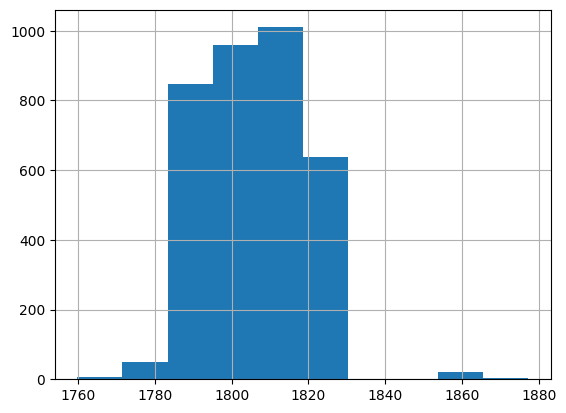

```python
linnean["datetime"].hist()
```

```python
# snadno se můžeme např. podívat pouze na dopisy odeslané před začátkem 19. století
linnean["18thcent?"] = linnean["datetime"] < pd.to_datetime("1801-01-01")
# jen pro ověření se podívejme na prvních 5 řádek takto filtrovaných dat
linnean[linnean["18thcent?"]].head(5)
```

|  | id | sender_surname | sender_forename | recipient_surname | recipient_forename | sorting_date | date | sender_address | recipient_address | source | languages | extent | filename | datetime | 18thcent? |
| --- | --- | --- | --- | --- | --- | --- | --- | --- | --- | --- | --- | --- | --- | --- | --- |
| 1 | LINNEAN2 | Butt | John Martin | Smith | Sir James Edward | 1798-09-17 | 17 Sep 1798 | Witley, Worcestershire | NaN | GB-110/JES/ADD/10, The Linnean Society of London | eng | NaN | LINNEAN2.xml | 1798-09-17 | True |
| 4 | LINNEAN5 | Teesdale | Robert | Smith | Sir James Edward | 1789-11-18 | 18 Nov 1789 | London | London | GB-110/JES/ADD/102, The Linnean Society of London | eng | NaN | LINNEAN5.xml | 1789-11-18 | True |
| 5 | LINNEAN6 | Thunberg | Carl Peter | Smith | Sir James Edward | 1792-06-26 | 26 Jun 1792 | Uppsala, Sweden | NaN | GB-110/JES/ADD/103, The Linnean Society of London | fre | NaN | LINNEAN6.xml | 1792-06-26 | True |
| 7 | LINNEAN8 | Treschow | H | Smith | Sir James Edward | 1794-07-08 | 8 Jul 1794 | Copenhagen, Denmark | NaN | GB-110/JES/ADD/105, The Linnean Society of London | eng | NaN | LINNEAN8.xml | 1794-07-08 | True |
| 9 | LINNEAN10 | Camper | Petrus | Smith | Sir James Edward | 1788-06-22 | [22 Jun 1788] | The Hague, Netherlands | London | GB-110/JES/ADD/107, The Linnean Society of London | eng | NaN | LINNEAN10.xml | 1788-06-22 | True |

Vlastní jméno odesilatele a příjemce se nám rozpadá do vícero sloupců ("sender_surname", "sender_forename"). Vytvořme si nyní agregovanou podobu jména.

```python
linnean["sender_agr"] = linnean.apply(lambda row: str(row["sender_surname"]).replace(" ", "_") + "_" + str(row["sender_forename"]).replace(" ", "_"), axis=1)
linnean["recipient_agr"] = linnean.apply(lambda row: str(row["recipient_surname"]).replace(" ", "_") + "_" + str(row["recipient_forename"]).replace(" ", "_"), axis=1)
```

Nyní se podíváme na osoby, který poslaly a přijaly největší množství dopisů:

```python
linnean["sender_agr"].value_counts()
```

```
sender_agr
Smith_Sir_James_Edward       481
Goodenough_Samuel            222
Woodward_Thomas_Jenkinson    101
Roscoe_William                98
Johnes_Thomas                 84
                            ...
Erskine_David_Steuart          1
Upcher_Abbot                   1
Walcott_William                1
Baker_William_Lloyd            1
Cullen_Charles_Sinclair        1
Name: count, Length: 457, dtype: int64
```

```python
linnean["recipient_agr"].value_counts()
```

```
recipient_agr
Smith_Sir_James_Edward    2948
Macleay_Alexander          102
Smith_Pleasance             72
Roscoe_William              53
Unknown_nan                 51
                          ...
Sutton_Charles               1
Brandreth_Mrs                1
Bright_Richard               1
Walker_George                1
Reeve_Robert                 1
Name: count, Length: 65, dtype: int64
```

V obou případech vidíme na prvním místě *Sira Jamese Edwarda Smithe*. Což, víme-li něco o Linneovské společnosti nebo podíváme-li se na wikipedii, není příliš překvapivé: jedná se o samotného zakladatele a dlouholetého předsedu této společnosti (viz wikipedia)).

V druhé tabulce vidíme na třetím místě také jeho manželku, *Pleasance Smithovou*, která byla taktéž významnou osobností dobového dění (taktéž viz [wikipedie](https://en.wikipedia.org/wiki/Pleasance_Smith)).

### Tvorba síťových dat

Pro potřeby následujících analýz si naše data výrazně přeskupíme a přetvoříme do podoby *seznamu vážených vazeb*.

```python
linnean_edges = linnean.groupby(["sender_agr", "recipient_agr"]).size().reset_index()
linnean_edges.columns = ["sender_agr", "recipient_agr", "letters_n"]
linnean_edges.head()
```

|  | sender_agr | recipient_agr | letters_n |
| --- | --- | --- | --- |
| 0 | Abbot_Charles | Smith_Sir_James_Edward | 18 |
| 1 | Acharius_Erik | Smith_Sir_James_Edward | 8 |
| 2 | Acrel_Johan_Gustaf | Smith_Sir_James_Edward | 7 |
| 3 | Afzelius_Adam | Smith_Sir_James_Edward | 14 |
| 4 | Aiton_William_Townsend | Smith_Sir_James_Edward | 1 |

Jednotkou pozorování (čili řádkou tabulky) nyní již není každý jednotlivý dopis, ale pár odesilatele a příjemce s informací, kolik odesilatel příjemci zaslal dopisů (viz sloupec `"letters_n"`). Tato data lze již v podstatě považovat za tabulku hran. Můžeme si je setřídit od těch s největší váhou (tj. s nejvyšším počtem dopisů poslaných daným směrem).

```python
linnean_edges.sort_values("letters_n", ascending=False)
```

[output not shown]

Z těchto dat si nyní vytvoříme síťový objekt.

```python
G = nx.from_pandas_edgelist(linnean_edges, 'sender_agr', 'recipient_agr', 'letters_n', create_using=nx.DiGraph())
```

```python
type(G)
```

```
networkx.classes.digraph.DiGraph
```

Základní vlastnosti, které nás o našem grafu zajímají jsou, kolik má uzlů a kolik má hran?

```python
G.number_of_nodes()
```

```
476
```

```python
G.number_of_edges()
```

```
534
```

Další užitečnou informací je, kolik mají uzle v průměru vazeb (tzv. avarege degree).

```python
sum(dict(G.degree).values()) / G.number_of_nodes()
```

```
2.2436974789915967
```

Stejně tak zajímavé bude se podívat, které uzly mají nejvyšší *in-degree* (tj. vazeb do něj vstupujících) a *out-degree* (tj. vazeb z něj vystupujících). Podívejme se na deset uzlů s nejvyšší hodnotou in-degree:

```python
sorted(dict(G.in_degree()).items(), key=lambda item: item[1], reverse=True)[:10]
```

```
[('Smith_Sir_James_Edward', 445),
 ('Unknown_nan', 14),
 ('Smith_Pleasance', 6),
 ('Cullum_Sir_Thomas_Gery', 4),
 ('Lambert_Aylmer_Bourke', 2),
 ('Wallich_Nathaniel', 2),
 ('Goodenough_Samuel', 2),
 ('The_Linnean_Society_nan', 2),
 ('Banks_Sir_Joseph', 1),
 ('Barrington_Shute', 1)]
```

Vidíme, že zcela ústřední pozici zde zaujímá *Sir James Edward Smith*, zakladatel a dlouholetý předseda společnosti. Hned na druhém místě se v jednom uzlu potkávají dopisy, jejichž adresát je neznámý. Nebude od věci tento uzel ze sítě zcela odstranit.

```python
G.remove_node("Unknown_nan")
```

Utvořený síťový graf si můžeme bezprostřdně vizualizovat pomocí funkce `nx.draw()`:

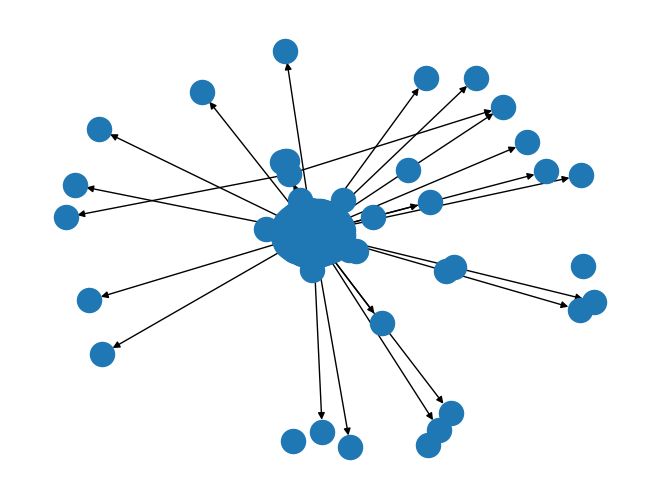

```python
nx.draw(G)
```

Bohužel vidíme, že výsledek vypadá spíše nevábně. Podle všeho se zde příliš mnoho uzlů poblíž středu. Vidíme, že vazby mají podobu šipek. Je tomu tak proto, že se jedná o tzv. směrový graf.

Abychom dosáhli lepších výsledků, přidáme do vizualizační funkce několik dodatečných parametrů

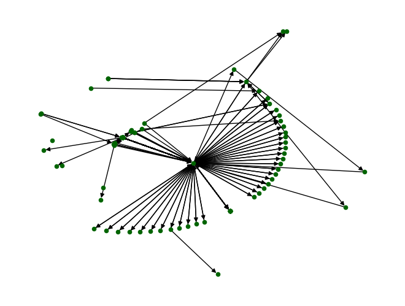

```python
my_color = "darkgreen" # vybereme jakoukoli jinou barvu odtud: https://matplotlib.org/stable/gallery/color/named_colors.html
nx.draw(G, node_size=20, node_color=my_color, pos=nx.kamada_kawai_layout(G))
```

```python
# Tato buňka slouží ke kontrole průchodu tímto cvičením.
# Pokud toto cvičení plníte v rámci svých studijních povinností na ZČU, buňku spusťte a držte se instrukcí.
import requests
exec(requests.get("https://sciencedata.dk/shared/856b0a7402aa7c7258186a8bdb329bd3?download").text)
kontrola_pruchodu(ntb="site", arg1=my_color)
```

Uzly v grafu se jmenují stejně jako korespondenti. Pomocí syntaxe níže se tak můžeme podívat na vlastnosti jednotlivých vazeb.

```python
G["Smith_Sir_James_Edward"]["Macleay_Alexander"]
```

```
{'letters_n': 102}
```

```python
G["Macleay_Alexander"]["Smith_Sir_James_Edward"]
```

```
{'letters_n': 74}
```

Zde se dozvídáme, že zatímco Sir James Edward Smith poslal Alexanderu Macleayovi 102, v opačném směru jich šlo 74.

Pro některé typy analýz je praktičtější i smysluplnější pracovat s nesměrovým grafem. Vazba tak nezohledňuje směr příslušné korespondence a váha může odpovídat součtu vyměněných dopisů v obou směrech. Transformovat naši síť do této podoby vyžaduje několik řádek kódu, jimiž se zde nemusíme příliš zaobírat, důležitější je výsledek.

```python
to_remove = []
edges_met = []
for node1, node2 in G.edges():
    if (G.has_edge(node2, node1)) & ((node2, node1) not in edges_met):
        G[node1][node2]["letters_n"] = G[node1][node2]["letters_n"] + G[node2][node1]["letters_n"]
        to_remove.append((node2, node1))
    edges_met.append((node1, node2))
```

```python
for u,v in to_remove:
    G.remove_edge(u,v)
```

```python
G = G.to_undirected().copy()
```

```python
len(G.edges())
```

```
484
```

Zde nyní uvidíme, že v obou směrech je hodnota "letters_n" totožná:

```python
G["Smith_Sir_James_Edward"]["Macleay_Alexander"]
```

```
{'letters_n': 176}
```

```python
G["Macleay_Alexander"]["Smith_Sir_James_Edward"]
```

```
{'letters_n': 176}
```

```python
weighted_degrees = {}
for node in G.nodes():
    weighted_degrees[node] = G.degree(node, weight='letters_n')
```

```python
list(weighted_degrees.items())[:10]
```

```
[('Abbot_Charles', 18),
 ('Smith_Sir_James_Edward', 3418),
 ('Acharius_Erik', 8),
 ('Acrel_Johan_Gustaf', 7),
 ('Afzelius_Adam', 14),
 ('Aiton_William_Townsend', 1),
 ('Allioni_Carlo', 7),
 ('Anderson_Alexander', 2),
 ('Anderson_James', 2),
 ('Anguish_Mrs_S', 1)]
```

```python
# tento degree učiníme atributem našich uzlů
nx.set_node_attributes(G, weighted_degrees, 'weighted_degree')
```

Nyní si vyjmeme pouze uzly, které mají stupeň (degree) alespoň roven 2, tj. uzly osob, kteří v našem datasetu vedly korespondenci s více než jednou osobou.

```python
node_list = [node for node in G.nodes if G.degree(node) >= 2]
len(node_list)
```

```
28
```

Ukazuje se, že takových uzlů je v našem datasetu relativně málo. Vypišme si jejich jména.

```python
node_list
```

```
['Smith_Sir_James_Edward',
 'Barrington_Jane',
 'Lambert_Aylmer_Bourke',
 'Sutton_Charles',
 'Bicheno_James_Ebenezer',
 'Forster_Edward',
 'Boyd_George',
 'Roxburgh_William',
 'Brodie_James',
 'Coke_Thomas_William',
 'Wallich_Nathaniel',
 'Crowe_James',
 'Cullum_Sir_Thomas_Gery',
 'Smith_Pleasance',
 'Davy_Martin',
 'Don_George',
 'Goodenough_Samuel',
 'Drake_William_Fitt',
 'Gemmellaro_Carlo',
 'The_Linnean_Society_nan',
 'Gurney_Anna',
 'Harriman_John',
 'Johnes_Thomas',
 'Latham_John',
 'Martyn_Thomas',
 'Smith_James',
 'Swartz_Olof_Peter',
 'Webb_William']
```

Nyní tento seznam jmen využijeme k vymezení výseku z našeho grafu (nazveme si jej `Gsub`), který bude zahrnovat pouze tyto uzly.

```python
Gsub = G.subgraph(node_list)
```

```
(-1.3, 1.3)
```

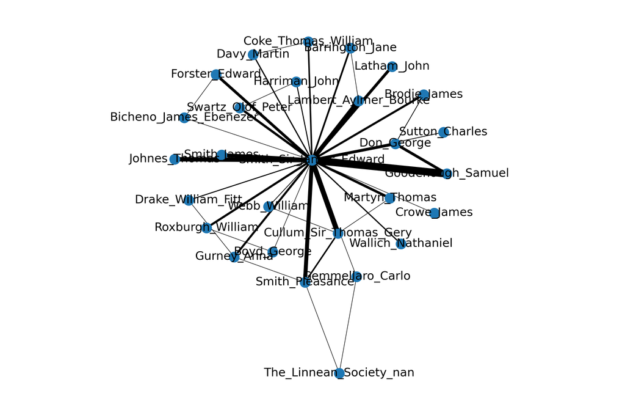

```python
fig, ax = plt.subplots(1,1, figsize=(9, 6), dpi=300, tight_layout=True)

# pro potřeby vizualizace si ještě definujeme šířku čar jednotlivých vazeb,vycházející z objemu vyměněných dopisů.
edge_widths = [np.sqrt(d['letters_n']) / 2 for (u, v, d) in Gsub.edges(data=True)]


nx.draw(Gsub, with_labels=True, pos=nx.kamada_kawai_layout(Gsub), node_size=100, nodelist=node_list, width=edge_widths, ax=ax)

ax.set_xlim(-1.3, 1.3)
```

Z takovéto vizualizace již lze vypozorovat leccos.

## Cvičení 2: Britská vědecká korespondence dlouhého 19. století jako celek

### Extrace a předzpracování dat

Nyní se vrátíme na začátek. Projekt Ɛpsilon totiž hostí vícero kolekcí dopisů z podobného období a je na místě očekávat, že se osoby v těchto kolekcích budou alespoň částečně překrývat.

Vypišme si tedy nejprve jména csv souborů s metadaty k těmto kolekcím.

```python
resp_json = requests.get("https://api.github.com/repos/cambridge-collection/epsilon-data/contents/csv/").json()
download_urls = [item["download_url"] for item in resp_json]
download_urls
```

```
['https://raw.githubusercontent.com/cambridge-collection/epsilon-data/main/csv/ampere.csv',
 'https://raw.githubusercontent.com/cambridge-collection/epsilon-data/main/csv/darwin-correspondence.csv',
 'https://raw.githubusercontent.com/cambridge-collection/epsilon-data/main/csv/darwin-family-letters.csv',
 'https://raw.githubusercontent.com/cambridge-collection/epsilon-data/main/csv/faraday.csv',
 'https://raw.githubusercontent.com/cambridge-collection/epsilon-data/main/csv/henslow.csv',
 'https://raw.githubusercontent.com/cambridge-collection/epsilon-data/main/csv/herschel.csv',
 'https://raw.githubusercontent.com/cambridge-collection/epsilon-data/main/csv/kemp.csv',
 'https://raw.githubusercontent.com/cambridge-collection/epsilon-data/main/csv/linnean-society.csv',
 'https://raw.githubusercontent.com/cambridge-collection/epsilon-data/main/csv/royal-society.csv',
 'https://raw.githubusercontent.com/cambridge-collection/epsilon-data/main/csv/somerville.csv',
 'https://raw.githubusercontent.com/cambridge-collection/epsilon-data/main/csv/tyndall.csv']
```

Nyní pomocí cyklu FOR načteme data ze všech těchto souborů a nakonec je spojíme do jednoho objektu type `pd.DataFrame`.

```python
dfs = [] # připrav prázdný seznam, který budeme následně postupně plnit daty z jednotlivých kolekcí
for url in download_urls: # pro každý z našeho seznamu souborů:
    try: # zkus: jej načíst jako dataframe
        collection_df = pd.read_csv(url, on_bad_lines='skip')
        collection_df["source"] = url.rpartition("/")[2] # přidej tomuto dataframu nový sloupec "source", kde bude uvedeno jméno souboru, ze kterého pochází
        dfs.append(collection_df) # přidej do seznamu aktuální dataframe
    except: # pokud to nejde:
        print("failed: ", url) # vypiš jméno souboru, u kterého to nejde
epsilon = pd.concat(dfs) # spoj do jednoho všechny dataframy uvnitř seznamu dfs
```

```python
epsilon.head(5)
```

|  | id | sender_surname | sender_forename | recipient_surname | recipient_forename | sorting_date | date | sender_address | recipient_address | source | languages | extent | filename |
| --- | --- | --- | --- | --- | --- | --- | --- | --- | --- | --- | --- | --- | --- |
| 0 | L1 | Ampère | Jeanne-Antoinette (mère d'Ampère) | Ampère | André-Marie | 1775-01-01 | s.d. | NaN | NaN | ampere.csv | fra | NaN | L1.xml |
| 1 | L2 | Maine de Biran | Pierre | Ampère | André-Marie | 1807-03-15 | 15 mars 1807 | NaN | NaN | ampere.csv | fra | NaN | L2.xml |
| 2 | L3 | Ampère | André-Marie | Ampère | Jean-Jacques (fils d'Ampère) | 1775-01-01 | s.d. | NaN | NaN | ampere.csv | fra | NaN | L3.xml |
| 3 | L4 | Ampère | André-Marie | Duhamel | Jean-Marie | 1775-01-01 | s.d. | NaN | NaN | ampere.csv | fra | NaN | L4.xml |
| 4 | L5 | Ampère | André-Marie | Duhamel | Jean-Marie | 1775-01-01 | s.d. | NaN | NaN | ampere.csv | fra | NaN | L5.xml |

```python
# jak dlouhý je náš dataset?
len(epsilon)
```

```
48995
```

```python
# stejně jako výše agregujme jména autorů a příjemců dopisů do podoby bez mezer a závorek
epsilon["sender_agr"] = epsilon.apply( lambda row: str(row["sender_surname"]).replace(" ", "_").partition(" (")[0] + "_" + str(row["sender_forename"]).replace(" ", "_").partition(" (")[0], axis=1)
epsilon["sender_agr"] = epsilon["sender_agr"].apply(lambda x: regex.sub(r"[^\p{L}_-]", "", x))

epsilon["recipient_agr"] = epsilon.apply( lambda row: str(row["recipient_surname"]).replace(" ", "_").partition(" (")[0] + "_" + str(row["recipient_forename"]).replace(" ", "_").partition(" (")[0], axis=1)
epsilon["recipient_agr"] = epsilon["recipient_agr"].apply(lambda x: regex.sub(r"[^\p{L}_-]", "", x))

# odstraníme neznáme odesilatele a příjemce
epsilon = epsilon[~epsilon.isin(["Unknown_nan", "AT_TO_LOOK", "nan_nan"]).any(axis=1)]
```

Díky attributu "source" se vždy můžeme podívat pouze na výsek dat z konkrétního zdroje:

```python
epsilon[epsilon["source"]=="darwin-family-letters.csv"].head(5)
```

|  | id | sender_surname | sender_forename | recipient_surname | recipient_forename | sorting_date | date | sender_address | recipient_address | source | languages | extent | filename | sender_agr | recipient_agr |
| --- | --- | --- | --- | --- | --- | --- | --- | --- | --- | --- | --- | --- | --- | --- | --- |
| 0 | FL-0001 | Darwin | G. H. | Darwin | Emma | 1868-03-01 | [late March 1868] | NaN | NaN | darwin-family-letters.csv | NaN | NaN | FL-0001.xml | Darwin_G_H | Darwin_Emma |
| 1 | FL-0002 | Darwin | G. H. | Darwin | H. E. | 1869-04-13 | [probably 13 April 1869] | 84. Chps. Elysées | NaN | darwin-family-letters.csv | NaN | NaN | FL-0002.xml | Darwin_G_H | Darwin_H_E |
| 2 | FL-0003 | Darwin | G. H. | Darwin | H. E. | 1873-01-25 | 25 January 1873 | Hotel de Provence \| Cannes | NaN | darwin-family-letters.csv | NaN | NaN | FL-0003.xml | Darwin_G_H | Darwin_H_E |
| 3 | FL-0004 | Darwin | G. H. | Darwin | Emma | 1873-02-27 | 27 February [1873] | Hotel de Provence, Cannes | NaN | darwin-family-letters.csv | NaN | NaN | FL-0004.xml | Darwin_G_H | Darwin_Emma |
| 4 | FL-0005 | Darwin | G. H. | Darwin | Emma | 1873-03-03 | 3 March 1873 | Hotel de Provence \| Cannes | NaN | darwin-family-letters.csv | NaN | NaN | FL-0005.xml | Darwin_G_H | Darwin_Emma |

Vypišme si nejplodnější autory a nejpopulárnější příjemce:

```python
epsilon["sender_agr"].value_counts()
```

```
sender_agr
Darwin_C_R             8151
Herschel_Sir_John      5353
Faraday_Michael        2984
Tyndall_John           1146
Darwin_Emma             884
                       ...
Fry_C_E                   1
Radovanović_Marinko       1
Adams_A_L                 1
Ledeganck_Kasimir         1
Bohn_Johann_C             1
Name: count, Length: 5772, dtype: int64
```

```python
epsilon["recipient_agr"].value_counts()
```

```
recipient_agr
Herschel_Sir_John                9305
Darwin_C_R                       6713
Smith_Sir_James_Edward           2946
Faraday_Michael                  2102
Tyndall_John                     1291
                                 ...
Avogadro_Amedeo                     1
Herbert_Faraday_Jacob               1
Ehrenberg_Christian_Gottfried       1
Sievier_Robert_William              1
Clausius_Adelheid                   1
Name: count, Length: 3895, dtype: int64
```

Tentokrát si data vazeb do nesměrové podoby převedeme ještě před vytvořením grafu.

```python
epsilon_temp = epsilon.apply(lambda row: pd.Series(sorted([str(row["sender_agr"]), str(row["recipient_agr"])])), axis=1)
epsilon_temp.columns = ["node1", "node2"]
epsilon_edges = epsilon_temp.groupby(["node1", "node2"]).size().reset_index()
epsilon_edges.columns = ["node1", "node2", "weight"]
epsilon_edges = epsilon_edges[epsilon_edges["node1"] != epsilon_edges["node2"]]
epsilon_edges.head(5)
```

|  | node1 | node2 | weight |
| --- | --- | --- | --- |
| 0 | AB_Hewetson_nan | Tristram_Henry_Baker | 1 |
| 1 | AB_nan | Faraday_Michael | 2 |
| 2 | AW_Williamson_Foreign_Secretary_Royal_Society | Williamson_Alexander_William | 1 |
| 3 | A_B | Royal_Society_nan | 1 |
| 4 | A_H_White_Royal_Society | R_L_Sheppard_Tropical_Diseases_Bureau | 1 |

Data v této podobě můžeme již neprodleně použít k tvorbě sítě váženého nesměrového grafu.

```python
G = nx.from_pandas_edgelist(epsilon_edges, 'node1', 'node2', 'weight')
```

Opět se nejprve podíváme, z kolika uzlů a kolika hran naše síť sestává:

```python
G.number_of_nodes()
```

```
7608
```

```python
G.number_of_edges()
```

```
9018
```

Z těchto dat lze také snadno vypočítat tzv. *average degree*:

```python
(2 * G.number_of_edges()) / G.number_of_nodes()
```

```
2.3706624605678233
```

U grafu s takto velkým počtem uzlů se nezřídka stane, že se ukáže, že je ve skutečnosti tvořen několika oddělenými komponenty, čili že síť není zcela propojená.

```python
len(list(nx.connected_components(G)))
```

```
175
```

Ano, to je i náš případ zde, když máme co dočinění s grafem, který sestává z více než 160 komponentů.

Podívejme se, z kolika uzlů sestává deset největších komponentů:

```python
components_sorted = sorted(list(nx.connected_components(G)), key=len, reverse=True)
[len(comp) for comp in components_sorted][:10]
```

```
[7235, 5, 4, 4, 4, 3, 3, 3, 3, 3]
```

Vidíme, že většina uzlů je součástí největšího komponentu, druhý největší komponent sestává již pouze z 5 uzlů. S klidným svědomím se nyní zaměříme pouze na největší komponent naší sítě.

```python
len(components_sorted[0])
```

```
7235
```

```python
# Omezíme se na největší komponent.
G = G.subgraph(list(components_sorted[0]))
```

```python
G.number_of_nodes() #zkontrolujeme, že se filtrace uzlů povedla
```

```
7235
```

```python
(2 * G.number_of_edges()) / G.number_of_nodes()
```

```
2.437595024187975
```

Pro potřeby několika dalších vizualizací nyní všem uzlům v rámci této sítě přiřadíme pozici v prostoru na základě jejich strukturelního postavení. Přiřazení těchto pozic v případě sítě, která sestává z tisíců uzlů, může být výpočetně poměrně náročné a zabrat nějaký čas. Abychom se níže vyhnuli zbytečnému čekání, vypočteme si tyto pozice uzlů již zde a dále je budeme používat v několika vizualizacích po sobě.

```python
%%time
pos = nx.spring_layout(G)
```

```
CPU times: user 50.1 s, sys: 369 ms, total: 50.5 s
Wall time: 51 s
```

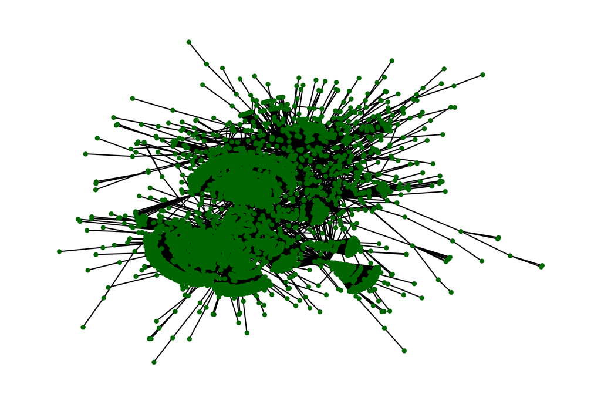

```python
fig, ax = plt.subplots(figsize=(9,6), dpi=300)
nx.draw(G, node_size=10, node_color="darkgreen", pos=pos, ax=ax)
```

```python
# Tato buňka slouží ke kontrole průchodu tímto cvičením.
# Pokud toto cvičení plníte v rámci svých studijních povinností na ZČU, buňku spusťte a držte se instrukcí.
kontrola_pruchodu(ntb="site", arg1="site2")
```

> Zde končí povinná část cvičení.

Tato síť již možná má některé zajímavé topografické vlastnosti, které si zaslouží bližší analytické ohledání.

### Metriky centrality

- **degree centrality**: je definován počtem vazeb, které daný uzel má
- **closeness centrality**: součet vzdáleností nejkratších cest potřebných k dosažení všech ostatních uzlů uvnitř sítě.
- **betweenness centrality** (mezilehlost): Jak často se ten který uzel nachází na trase spojující nejkratší cestou jakékoli další uzly uvnitř sítě.
- **PageRank centrality**: je určen mnohonásobně opakovanými náhodnými procházkami po síti. Velikost PageRank je určena množstvím návštěv daného uzlu při těchto procházkách. Tento algoritmus byl původně vyvinut vývojáři od společnosti Google pro určení důležitých webových stránek.

```python
degree_centrality = nx.degree_centrality(G)
degree_top_nodes = sorted(degree_centrality.items(), key=lambda x:x[1], reverse=True)
degree_top_nodes[:10]
```

```python
pagerank_centrality = nx.pagerank(G, max_iter=10000)
pagerank_top_nodes = sorted(pagerank_centrality.items(), key=lambda x:x[1], reverse=True)
pagerank_top_nodes[:10]
```

```python
%%time
betweenness_centrality = nx.betweenness_centrality(G)
betweenness_top_nodes = sorted(betweenness_centrality.items(), key=lambda x:x[1], reverse=True)
betweenness_top_nodes[:10]
```

```python
degree_pagerank_comparison = []
for deg, page, betw in zip(degree_top_nodes, pagerank_top_nodes, betweenness_top_nodes):
    degree_pagerank_comparison.append([deg[0], page[0], betw[0]])
centr_comparison_df = pd.DataFrame(degree_pagerank_comparison)
centr_comparison_df.columns = ["degree_node", "pagerank_node", "betw_node"]
print(centr_comparison_df.head(20).round(2))
```

[output not shown]

```python
for node in centr_comparison_df["betw_node"][:20]:
    print(node, " degree:", G.degree(node), "degree rank:", [el[0] + 1 for el in enumerate(degree_top_nodes) if el[1][0] == node][0], )
```

[output not shown]

Podívejme se nyní čtyři osobnosti:

- Charles Lyell
- Francis Galton
- John Phillips
- John Lubbock

Vytvořme tedy novou vizualizaci, v rámci které zaostříme pozornost právě na 20 uzlů s největší *betweenness*. Tyto uzly vyobrazíme odlišnou barvou a stejnou barvou vyobrazíme i jejich jména.

```python
special_nodes = centr_comparison_df["betw_node"][:20] #["Lyell_Charles", "Galton_Francis", "Phillips_John", "Lubbock_John"]
special_pos = dict([(node, pos[node]) for node in special_nodes])
labels = {node: node for node in special_nodes}
```

```python
fig, ax = plt.subplots(figsize=(24,18), dpi=300)
special_nodes_color = "darkorange"
nx.draw(G, node_size=10, node_color="black", edge_color="grey",pos=pos, ax=ax, alpha=0.5)
nx.draw_networkx_nodes(G, nodelist=special_nodes, node_size=50, node_color=special_nodes_color, pos=special_pos, ax=ax)
nx.draw_networkx_labels(G, font_color=special_nodes_color, pos=special_pos, labels=labels,ax=ax)
```

[output not shown]

```python
try:
    fig.savefig("../figures/epsilon_betw.png") # pokud pracujeme s repozitoří jako celkem, včetně podlsožky "figures"
except:
    fig.savefig("epsilon_betw.png") # pokud pracujeme s notebookem samostatně, např. přes Google Colab
```

### Detekce komunit

Další důležitou rodinou algoritmů jsou algoritmy pro detekování komunit, neboli shluků uzlů, které jsou mezi sebou provázány více, než z uzly z jejich okolí. Zde použijeme takzvanou Lovaňskou metodu (podle působiště výzkumníků, kteří ji vyvinuli [viz [wikipedia](https://en.wikipedia.org/wiki/Louvain_method)]). Tento algoritmus se snaží nalézt takové rozdělení uzlů do komunit, které maximalizuje poměr vazeb mezi uzly uvnitř těchto komunit oproti jejich vazbám směrem ven z těchto komunit.

```python
from networkx.algorithms import community
communities = nx.community.louvain_communities(G, seed=1)
len(communities)
```

[output not shown]

```python
[len(com) for com in communities]
```

```python
cmap = plt.get_cmap('viridis')
colors = [cmap(i) for i in np.linspace(0, 1, len(communities))]

fig, ax = plt.subplots(figsize=(24,18), dpi=300)
nx.draw_networkx_edges(G, edge_color="grey",pos=pos, alpha=0.5, ax=ax)

for community, color in zip(communities, colors):
    special_pos = dict([(node, pos[node]) for node in list(community)])
    #nx.draw(G, node_size=10, node_color="black", edge_color="grey",pos=pos, ax=ax, alpha=0.5)
    nx.draw_networkx_nodes(G, nodelist=list(community), node_size=10, node_color=[color], pos=special_pos, ax=ax)
ax.axis('off')
```

[output not shown]

## Alternativní datová sada: CorrespSearch

Alternativně bychom celé cvičení mohli absolvovat za využití mnoha dalších datasetů. Jedním z nich je dataset dostupný přes API na platformě CorrespSearch ([web](https://correspsearch.net/en/home.html)).

```python
correspsearch = pd.read_csv("https://correspsearch.net/api/v2.0/csv.xql?", sep=";")
correspsearch.head(10)
```

```python
%%time
for n in range(2,30):
    page_df = pd.read_csv("https://correspsearch.net/api/v2.0/csv.xql?x=" + str(n), sep=";")
    correspsearch = pd.concat([correspsearch, page_df])
    if n in range(0,3000,100):
        print(n)
    if len(page_df) < 100:
        break
```

```python
len(correspsearch)
```

```python
correspsearch = correspsearch[correspsearch["sender"].notnull() & correspsearch["addressee"].notnull()]
len(correspsearch)
```